# Project 2 — Data Tidying: Business Costs and Revenue

Author

Esra Dogan

Published

October 11, 2026

## Introduction

This is one of the three datasets for Project 2. In this file, I will tidy Jocelyn’s Business Costs and Revenue dataset from 5A discussion posts. I will decide the tidying steps myself, based on what makes the data messy, and then use the analysis ideas Jocelyn suggested in her post.

## Source and Requested Analysis

This dataset is a CSV file that Jocelyn created, with monthly costs and revenues for five people in different US cities from January to June. She suggested calculating profits, plotting monthly trends by region, and looking at the national totals over the six months.

## Data Structure

The data is wide because each month has its own cost and revenue columns, like “Jan Cost” and “Jan Revenue”. In the tidy version, each row will show one location in one month, with location, name, month, cost, and revenue. I will keep cost and revenue as separate columns so I can easily calculate profit in each row.

## Planned Approach

First, I will upload Jocelyn’s CSV file to GitHub as it is, in its original wide format, and read it into R from there. After that, before cleaning the column names, I will convert the cost and revenue values to numbers and multiply the columns marked with (k) by 1,000, since this information is contained in the column names. Next, I will clean the column names so they all follow the same format. Because each column name holds two pieces of information, the month and whether it is a cost or a revenue, one pivot_longer() is not enough. So I will use pivot_longer(), split the name into month and measure, and then use pivot_wider() to turn cost and revenue back into their own columns.

Once the data is tidy, I will calculate profit for each row, plot the monthly trends by location, and add up the costs, revenues, and profits for all locations. I will use summary tables and ggplot2 charts, and end with a conclusion.

## Anticipated Challenges

The column names are inconsistent in three ways: different capital letters (“May Cost” and “may revenue”), underscores instead of spaces (“April_Cost”), and short and full month names (“Jan” and “March”). There is also an extra space after “Name”. The February and March costs are written in thousands (k), so I will multiply them by 1,000, and some January costs are stored as text with commas, like “29,000”, so I will change them to numbers. Boston’s May revenue is 6,150,000, which looks like a typo, so I will need to fix it or leave it out and explain my choice.

## Tidying the Data

### Loading the packages

```r
library(tidyverse)
```

The reason why I chose tidyverse is it includes both tidyr and dplyr also ggplot2. I found it useful.

### Reading CSV

I read Jocelyn’s raw CSV file from my GitHub repository and look at its column names, number of rows, and first few rows.

```r
# Import the raw wide-format data directly from GitHub
costs_raw <- read.csv(
  "https://raw.githubusercontent.com/esradogan3/Project_2/refs/heads/main/5A_BusinessCostsRevenue.csv",
  check.names = FALSE
)

# Structure before tidying
names(costs_raw)   # column names
```

```
 [1] "Location"       "Name"           "Jan Cost"       "Jan Revenue"
 [5] "Feb Cost (k)"   "Feb Revenue"    "March Cost (k)" "March Revenue"
 [9] "April_Cost"     "April_revenue"  "May Cost"       "may revenue"
[13] "June Cost"      "June Revenue"
```

```r
nrow(costs_raw)    # number of rows
```

```
[1] 5
```

```r
head(costs_raw)    # representative sample
```

```
  Location   Name Jan Cost Jan Revenue Feb Cost (k) Feb Revenue March Cost (k)
1   Boston  Bobby   29,000       50000         50.0       52000             40
2  Chicago Denise   41,000       45000         50.6       34000             14
3       LA  Ethan    30500       39000         31.0       38000             60
4 New York  April    19000       31500         22.0       31000             28
5   Dallas   Emma    38000       42000         16.0       58000             31
  March Revenue April_Cost April_revenue May Cost may revenue June Cost
1         48000      50000         53000    25000     6150000     45000
2         41000      56000         34000    14000       21000     38000
3         65000      60000         58000    36000       37000     62000
4         33000      30000         31000    37000       39500     29000
5         35000      35000         33000    24000       34000     20000
  June Revenue
1        44000
2        46000
3        55000
4        30000
5        28000
```

### Fixing the values before cleaning

I turn the cost and revenue values into numbers, multiply the “(k)” columns by 1,000, and clean all the column names so they follow the same format.

```r
# Step 1: Fix values before renaming, while the "(k)" labels are still there
costs_fixed <- costs_raw |>
  # Convert all cost and revenue columns to numbers
  # (parse_number removes commas, so "29,000" becomes 29000)
  mutate(across(matches("cost|revenue"), ~ parse_number(as.character(.x)))) |>
  # Columns labeled "(k)" are in thousands, so multiply them by 1,000
  mutate(across(contains("(k)"), ~ .x * 1000))

# Step 2: Clean column names so they all follow the same format
costs_clean <- costs_fixed |>
  rename_with(~ .x |>
                str_remove("\\(k\\)") |>          # remove the "(k)" label (already used)
                str_trim() |>                     # remove extra spaces, e.g. "Name "
                str_to_lower() |>                 # same case everywhere
                str_replace_all("[ _]+", "_") |>  # spaces and underscores become "_"
                str_replace("^([a-z]{3})[a-z]*_(cost|revenue)$", "\\1_\\2")  # "march" -> "mar"
  )

names(costs_clean)
```

```
 [1] "location"    "name"        "jan_cost"    "jan_revenue" "feb_cost"
 [6] "feb_revenue" "mar_cost"    "mar_revenue" "apr_cost"    "apr_revenue"
[11] "may_cost"    "may_revenue" "jun_cost"    "jun_revenue"
```

### Tidy Format

I reshape the data from wide to tidy format, so each row shows one location in one month, with separate columns for cost and revenue.

```r
costs_tidy <- costs_clean |>
  # Step 1: Make it long. Each column name like "jan_cost" is split
  # into two new columns: month ("jan") and measure ("cost")
  pivot_longer(
    cols = matches("_(cost|revenue)$"),
    names_to = c("month", "measure"),
    names_sep = "_",
    values_to = "amount"
  ) |>
  # Step 2: Put cost and revenue back into their own columns
  pivot_wider(
    names_from = measure,
    values_from = amount
  ) |>
  # Step 3: Keep months in calendar order, not alphabetical order
  mutate(month = factor(month, levels = c("jan", "feb", "mar", "apr", "may", "jun")))

costs_tidy
```

```
# A tibble: 30 × 5
   location name   month  cost revenue
   <chr>    <chr>  <fct> <dbl>   <dbl>
 1 Boston   Bobby  jan   29000   50000
 2 Boston   Bobby  feb   50000   52000
 3 Boston   Bobby  mar   40000   48000
 4 Boston   Bobby  apr   50000   53000
 5 Boston   Bobby  may   25000 6150000
 6 Boston   Bobby  jun   45000   44000
 7 Chicago  Denise jan   41000   45000
 8 Chicago  Denise feb   50600   34000
 9 Chicago  Denise mar   14000   41000
10 Chicago  Denise apr   56000   34000
# ℹ 20 more rows
```

Each column name holds two pieces of information: the month and the measure. So I used `pivot_longer()` to stack all month columns and split each name into a `month` column and a `measure` column. Then I used `pivot_wider()` to turn `cost` and `revenue` back into separate columns, because I need both in the same row to calculate profit. Finally, I set the months as a factor in calendar order, so tables and plots show January to June instead of alphabetical order.

### Checking missing and inconsistent values

I check the tidy data for missing values, inconsistent text, and unusual numbers before analyzing it.

```r
# 1. Count missing values in each column
costs_tidy |>
  summarise(across(everything(), ~ sum(is.na(.x))))
```

```
# A tibble: 1 × 5
  location  name month  cost revenue
     <int> <int> <int> <int>   <int>
1        0     0     0     0       0
```

```r
# 2. Check the text columns for spelling or spacing problems
costs_tidy |>
  distinct(location, name)
```

```
# A tibble: 5 × 2
  location name
  <chr>    <chr>
1 Boston   Bobby
2 Chicago  Denise
3 LA       Ethan
4 New York April
5 Dallas   Emma
```

```r
# 3. Look at the range of costs and revenues to spot unusual values
costs_tidy |>
  select(cost, revenue) |>
  summary()
```

```
      cost          revenue
 Min.   :14000   Min.   :  21000
 1st Qu.:25750   1st Qu.:  33250
 Median :33000   Median :  39250
 Mean   :35370   Mean   : 244533
 3rd Qu.:44000   3rd Qu.:  49500
 Max.   :62000   Max.   :6150000
```

```r
# 4. Show the rows with the highest revenue
costs_tidy |>
  arrange(desc(revenue)) |>
  head()
```

```
# A tibble: 6 × 5
  location name  month  cost revenue
  <chr>    <chr> <fct> <dbl>   <dbl>
1 Boston   Bobby may   25000 6150000
2 LA       Ethan mar   60000   65000
3 LA       Ethan apr   60000   58000
4 Dallas   Emma  feb   16000   58000
5 LA       Ethan jun   62000   55000
6 Boston   Bobby apr   50000   53000
```

The data has no missing values, but two values are inconsistent. Los Angeles is written as “LA”, while all other cities use their full names. Boston’s May revenue is 6,150,000, while every other revenue is between 21,000 and 65,000. The summary also shows the problem: the mean revenue is 244,533, while the median is only 39,250. This single value pulls the mean far above all the other revenues.

### Handling inconsistent values

I fix the inconsistent values I found: I use full city names and set Boston’s May revenue to missing.

I changed “LA” to “Los Angeles” so all locations follow the same naming style. Boston’s other monthly revenues are between 44,000 and 53,000, so 6,150,000 is almost certainly a typo. Since I cannot know the correct value, I set it to missing (`NA`) instead of guessing. This means Boston’s May profit will also be missing, and the national totals for May will include only four locations.

```r
costs_tidy <- costs_tidy |>
  mutate(
    # Use full city names for every location
    location = recode(location, "LA" = "Los Angeles"),
    # Boston's May revenue (6,150,000) is a clear typo, so set it to missing
    revenue = if_else(location == "Boston" & month == "may", NA_real_, revenue)
  )

# Show the row I changed
costs_tidy |>
  filter(location == "Boston", month == "may")
```

```
# A tibble: 1 × 5
  location name  month  cost revenue
  <chr>    <chr> <fct> <dbl>   <dbl>
1 Boston   Bobby may   25000      NA
```

## Analysis

### Calculating profit

I calculate the profit for each location and month by subtracting cost from revenue. Since Boston’s May revenue is missing, its May profit is also missing.

```r
costs_tidy <- costs_tidy |>
  mutate(profit = revenue - cost)

costs_tidy
```

```
# A tibble: 30 × 6
   location name   month  cost revenue profit
   <chr>    <chr>  <fct> <dbl>   <dbl>  <dbl>
 1 Boston   Bobby  jan   29000   50000  21000
 2 Boston   Bobby  feb   50000   52000   2000
 3 Boston   Bobby  mar   40000   48000   8000
 4 Boston   Bobby  apr   50000   53000   3000
 5 Boston   Bobby  may   25000      NA     NA
 6 Boston   Bobby  jun   45000   44000  -1000
 7 Chicago  Denise jan   41000   45000   4000
 8 Chicago  Denise feb   50600   34000 -16600
 9 Chicago  Denise mar   14000   41000  27000
10 Chicago  Denise apr   56000   34000 -22000
# ℹ 20 more rows
```

### Monthly profit trends by location

I plot the monthly profit for each location to compare their trends from January to June. Boston’s line has a gap in May because that value is missing.

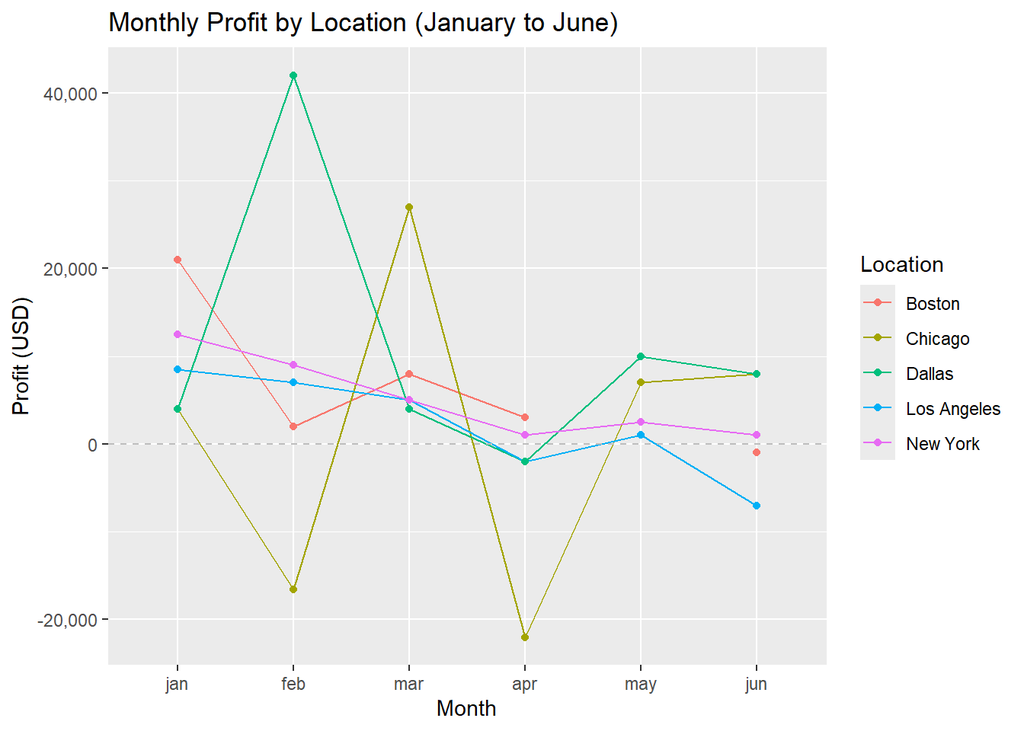

```r
ggplot(costs_tidy, aes(x = month, y = profit, color = location, group = location)) +
  geom_line() +
  geom_point() +
  geom_hline(yintercept = 0, linetype = "dashed", color = "gray") +
  scale_y_continuous(labels = scales::comma) +
  labs(
    title = "Monthly Profit by Location (January to June)",
    x = "Month",
    y = "Profit (USD)",
    color = "Location"
  )
```

### Total profit by location

I add up each location’s profit over the six months to see which locations did best overall. The months column shows how many months are included, because Boston’s May profit is missing.

```r
location_totals <- costs_tidy |>
  filter(!is.na(profit)) |>
  group_by(location) |>
  summarise(
    months = n(),
    total_cost_usd = sum(cost),
    total_revenue_usd = sum(revenue),
    total_profit_usd = sum(profit)
  ) |>
  arrange(desc(total_profit_usd))

location_totals
```

```
# A tibble: 5 × 5
  location    months total_cost_usd total_revenue_usd total_profit_usd
  <chr>        <int>          <dbl>             <dbl>            <dbl>
1 Dallas           6         164000            230000            66000
2 Boston           5         214000            247000            33000
3 New York         6         165000            196000            31000
4 Los Angeles      6         279500            292000            12500
5 Chicago          6         213600            221000             7400
```

### National totals by month

I add up the costs, revenues, and profits of all locations for each month. I leave out Boston’s May row because its revenue is missing, so the May totals include only four locations. The locations column shows how many locations are included in each month.

```r
national_totals <- costs_tidy |>
  filter(!is.na(revenue)) |>
  group_by(month) |>
  summarise(
    locations = n(),
    total_cost_usd = sum(cost),
    total_revenue_usd = sum(revenue),
    total_profit_usd = sum(profit)
  )

national_totals
```

```
# A tibble: 6 × 5
  month locations total_cost_usd total_revenue_usd total_profit_usd
  <fct>     <int>          <dbl>             <dbl>            <dbl>
1 jan           5         157500            207500            50000
2 feb           5         169600            213000            43400
3 mar           5         173000            222000            49000
4 apr           5         231000            209000           -22000
5 may           4         111000            131500            20500
6 jun           5         194000            203000             9000
```

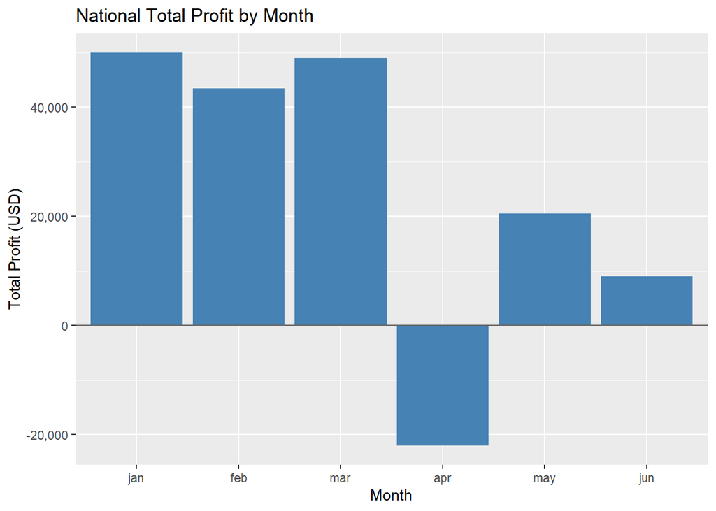

```r
ggplot(national_totals, aes(x = month, y = total_profit_usd)) +
  geom_col(fill = "steelblue") +
  geom_hline(yintercept = 0, color = "gray40") +
  scale_y_continuous(labels = scales::comma) +
  labs(
    title = "National Total Profit by Month",
    x = "Month",
    y = "Total Profit (USD)"
  )
```

## Conclusion

Across the six months, the five locations made a combined profit of 149,900 USD (not counting Boston in May). Dallas had the highest total profit, 66,000 USD, mostly because of a very strong February, when it earned 42,000 USD in profit from 58,000 USD in revenue and only 16,000 USD in costs. Boston (33,000 USD over five months) and New York (31,000 USD) came next. New York was the most stable location, with a positive profit in every month. Chicago had the lowest total profit, 7,400 USD, and the most ups and downs: it lost 16,600 USD in February and 22,000 USD in April, but earned 27,000 USD in March.

At the national level, profits were strongest in the first three months: 50,000 USD in January, 43,400 USD in February, and 49,000 USD in March. April was the only month with a national loss (−22,000 USD), because costs rose to 231,000 USD while revenue fell to 209,000 USD. Profits recovered in May (20,500 USD, with only four locations) and June (9,000 USD), but stayed well below the early months.

One limitation is Boston’s May revenue. I treated it as missing because 6,150,000 is clearly a typo, so the May totals are not fully comparable with the other months.

## Use of LLM

I used Claude (Anthropic) as an assistant for coding and writing support in this project. I reviewed, ran, and checked all code and results myself.

## References

Anthropic. (2026). Claude (Opus 5.5 version) [Large language model]. https://claude.ai